# Structural Causal Model: Simple Simulation

Anas Mourahib

2026-02-11

## Introduction

In this session, we simulate a simple structural causal model (SCM) using Gaussian noise.

The variables are generated according to:

- $X_1$ is independent
- $X_2$ depends on $X_1$
- $X_3$ depends on $X_1$
- $X_4$ depends on both $X_2$ and $X_3$

## Causal Graph

The associated directed acyclic graph (DAG) is:

Don’t forget to installe the package

```r
library(DiagrammeR)
grViz("
digraph scm {

  # Global node style
  node [
    shape = circle,
    style = filled,
    color = lightblue,
    fixedsize = true,
    width = 0.4,
    height = 0.4,
    fontsize = 10
  ]

  # Nodes
  X1; X2; X3; X4;

  # Edges (causal links)
  X1 -> X2;
  X1 -> X3;
  X2 -> X4;
  X3 -> X4;
}
")
```

[interactive chart not shown]

## Data Simulation

We simulate a Gaussian linear structural causal model with respect to the DAG above.

```r
set.seed(7)

# Generate variables from a simple SCM
X1 = rnorm(100)
X2 = X1 + rnorm(100)
X3 = X1 + rnorm(100)
X4 = X2 + X3 + rnorm(100)

# Store the dataset in a data frame
dat <- data.frame(X1, X2, X3, X4)

# Display the first few observations
head(dat)
```

```
##           X1         X2         X3         X4
## 1  2.2872472  2.8063055  4.3105912  7.6421583
## 2 -1.1967717 -0.6092320 -0.3342792 -1.2192385
## 3 -0.6942925 -0.7736256 -0.7192020 -1.4381178
## 4 -0.4122930 -1.5866540  0.1883420 -1.7865616
## 5 -0.9706733 -0.6619512  0.2458074 -0.8331669
## 6 -0.9472799 -2.5511585 -2.1238115 -5.8391451
```

## Scatter Plot Matrix

To visualize the relationships between variables, we plot pairwise scatter plots

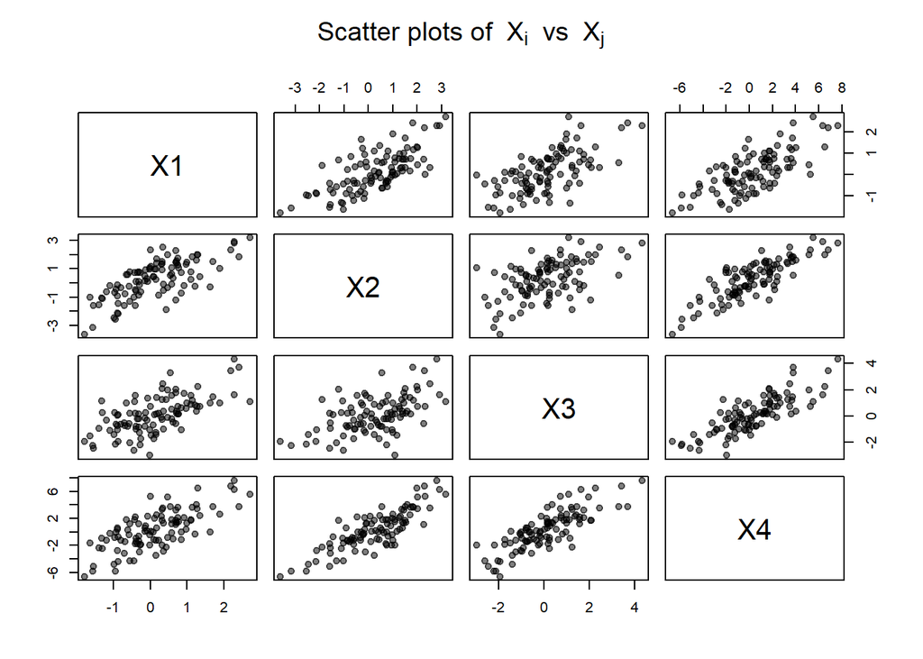

```r
pairs(dat,
      pch = 19,
      col = rgb(0, 0, 0, 0.5),
      main = expression("Scatter plots of " ~ X[i] ~ " vs " ~ X[j]))
```

## Interventions and causal links

Let $a = 1$, and consider the intervention $do(X_1 = a)$.

```r
set.seed(7)
a = 1
# Generate variables from a simple SCM
X1_i = a
X2_i = X1_i + rnorm(100)
X3_i = X1_i + rnorm(100)
X4_i = X2_i + X3_i + rnorm(100)

# Store the dataset in a data frame
dat_i <- data.frame(X1_i, X2_i, X3_i, X4_i)

# Display the first few observations
head(dat_i)
```

```
##   X1_i        X2_i       X3_i      X4_i
## 1    1  3.28724716  1.5190584  6.829650
## 2    1 -0.19677168  1.5875397  2.253261
## 3    1  0.30570749  0.9206669  1.201465
## 4    1  0.58770705 -0.1743610  1.013981
## 5    1  0.02932666  1.3087221  2.554530
## 6    1  0.05272005 -0.6038785 -1.727690
```

## Scatter Plot Matrix

To visualize the relationships between variables, we plot pairwise scatter plots

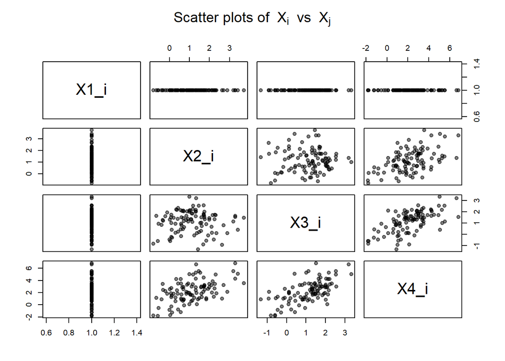

```r
pairs(dat_i,
      pch = 19,
      main = expression("Scatter plots of " ~ X[i] ~ " vs " ~ X[j]),
      panel = function(x, y, ...) {

        # If X1 is involved, color red
        if (all(x == dat$X1) || all(y == dat$X1)) {
          points(x, y, col = "red", pch = 19)
        } else {
          points(x, y, col = rgb(0, 0, 0, 0.5), pch = 19)
        }
      })
```

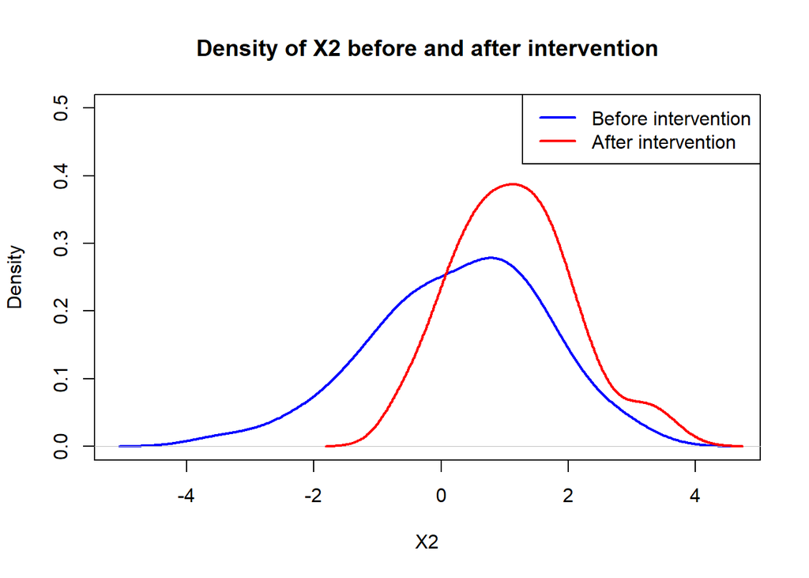

```r
# Compute kernel density estimates
dens_before <- density(X2)
dens_after  <- density(X2_i)

# Plot the first density
plot(dens_before,
     col = "blue",
     lwd = 2,
     main = "Density of X2 before and after intervention",
     xlab = "X2",
     ylab = "Density",
     ylim = c(0,0.5))

# Add the second density
lines(dens_after, col = "red", lwd = 2)

# Add a legend
legend("topright",
       legend = c("Before intervention", "After intervention"),
       col = c("blue","red"),
       lwd = 2)
```

# Conclusion

1. We have simulated from 4-dimensional Gaussian linear structural causal model
2. We performed a perfect intervention on one component of this structural causal model ($do(X_1 = a)$)
3. We studied the notion of causal link from one component to the other